# Coding Temple R-Programming Challenge: World Happiness Dataset

Ken Wood

2025-02-16

#### 1. Setting up the Environment

Import necessary libraries and load the dataset:

```r
library(tidyverse)
library(lubridate)
library(skimr)
library(dplyr)
whr <- read.csv("data/WHR2023.csv")
```

#### 2. Initial Exploration of the Dataset

Explore the structure and summary of the dataset:

```r
str(whr)  # View the structure of the dataset
```

```
## 'data.frame':    137 obs. of  19 variables:
##  $ Country.name                              : chr  "Finland" "Denmark" "Iceland" "Israel" ...
##  $ Ladder.score                              : num  7.8 7.59 7.53 7.47 7.4 ...
##  $ Standard.error.of.ladder.score            : num  0.036 0.041 0.049 0.032 0.029 0.037 0.044 0.043 0.069 0.038 ...
##  $ upperwhisker                              : num  7.88 7.67 7.62 7.54 7.46 ...
##  $ lowerwhisker                              : num  7.73 7.51 7.43 7.41 7.35 ...
##  $ Logged.GDP.per.capita                     : num  10.8 11 10.9 10.6 10.9 ...
##  $ Social.support                            : num  0.969 0.954 0.983 0.943 0.93 0.939 0.943 0.92 0.879 0.952 ...
##  $ Healthy.life.expectancy                   : num  71.2 71.2 72 72.7 71.5 ...
##  $ Freedom.to.make.life.choices              : num  0.961 0.934 0.936 0.809 0.887 0.948 0.947 0.891 0.915 0.887 ...
##  $ Generosity                                : num  -0.019 0.134 0.211 -0.023 0.213 0.165 0.141 0.027 0.024 0.175 ...
##  $ Perceptions.of.corruption                 : num  0.182 0.196 0.668 0.708 0.379 0.202 0.283 0.266 0.345 0.271 ...
##  $ Ladder.score.in.Dystopia                  : num  1.78 1.78 1.78 1.78 1.78 ...
##  $ Explained.by..Log.GDP.per.capita          : num  1.89 1.95 1.93 1.83 1.94 ...
##  $ Explained.by..Social.support              : num  1.58 1.55 1.62 1.52 1.49 ...
##  $ Explained.by..Healthy.life.expectancy     : num  0.535 0.537 0.559 0.577 0.545 0.562 0.544 0.582 0.549 0.513 ...
##  $ Explained.by..Freedom.to.make.life.choices: num  0.772 0.734 0.738 0.569 0.672 0.754 0.752 0.678 0.71 0.672 ...
##  $ Explained.by..Generosity                  : num  0.126 0.208 0.25 0.124 0.251 0.225 0.212 0.151 0.149 0.23 ...
##  $ Explained.by..Perceptions.of.corruption   : num  0.535 0.525 0.187 0.158 0.394 0.52 0.463 0.475 0.418 0.471 ...
##  $ Dystopia...residual                       : num  2.36 2.08 2.25 2.69 2.11 ...
```

```r
head(whr)  # Preview the first few rows
```

|  | Country.name | Ladder.score | Standard.error.of.ladder.score | upperwhisker | lowerwhisker | Logged.GDP.per.capita | Social.support | Healthy.life.expectancy | Freedom.to.make.life.choices | Generosity | Perceptions.of.corruption | Ladder.score.in.Dystopia | Explained.by..Log.GDP.per.capita | Explained.by..Social.support | Explained.by..Healthy.life.expectancy | Explained.by..Freedom.to.make.life.choices | Explained.by..Generosity | Explained.by..Perceptions.of.corruption | Dystopia...residual |
| --- | --- | --- | --- | --- | --- | --- | --- | --- | --- | --- | --- | --- | --- | --- | --- | --- | --- | --- | --- |
| 1 | Finland | 7.804 | 0.036 | 7.875 | 7.733 | 10.792 | 0.969 | 71.150 | 0.961 | -0.019 | 0.182 | 1.778 | 1.888 | 1.585 | 0.535 | 0.772 | 0.126 | 0.535 | 2.363 |
| 2 | Denmark | 7.586 | 0.041 | 7.667 | 7.506 | 10.962 | 0.954 | 71.250 | 0.934 | 0.134 | 0.196 | 1.778 | 1.949 | 1.548 | 0.537 | 0.734 | 0.208 | 0.525 | 2.084 |
| 3 | Iceland | 7.530 | 0.049 | 7.625 | 7.434 | 10.896 | 0.983 | 72.050 | 0.936 | 0.211 | 0.668 | 1.778 | 1.926 | 1.620 | 0.559 | 0.738 | 0.250 | 0.187 | 2.250 |
| 4 | Israel | 7.473 | 0.032 | 7.535 | 7.411 | 10.639 | 0.943 | 72.697 | 0.809 | -0.023 | 0.708 | 1.778 | 1.833 | 1.521 | 0.577 | 0.569 | 0.124 | 0.158 | 2.691 |
| 5 | Netherlands | 7.403 | 0.029 | 7.460 | 7.346 | 10.942 | 0.930 | 71.550 | 0.887 | 0.213 | 0.379 | 1.778 | 1.942 | 1.488 | 0.545 | 0.672 | 0.251 | 0.394 | 2.110 |
| 6 | Sweden | 7.395 | 0.037 | 7.468 | 7.322 | 10.883 | 0.939 | 72.150 | 0.948 | 0.165 | 0.202 | 1.778 | 1.921 | 1.510 | 0.562 | 0.754 | 0.225 | 0.520 | 1.903 |

```r
summary(whr)  # Summary statistics of the dataset
```

```
##  Country.name        Ladder.score   Standard.error.of.ladder.score
##  Length:137         Min.   :1.859   Min.   :0.02900
##  Class :character   1st Qu.:4.724   1st Qu.:0.04700
##  Mode  :character   Median :5.684   Median :0.06000
##                     Mean   :5.540   Mean   :0.06472
##                     3rd Qu.:6.334   3rd Qu.:0.07700
##                     Max.   :7.804   Max.   :0.14700
##
##   upperwhisker    lowerwhisker   Logged.GDP.per.capita Social.support
##  Min.   :1.923   Min.   :1.795   Min.   : 5.527        Min.   :0.3410
##  1st Qu.:4.980   1st Qu.:4.496   1st Qu.: 8.591        1st Qu.:0.7220
##  Median :5.797   Median :5.529   Median : 9.567        Median :0.8270
##  Mean   :5.667   Mean   :5.413   Mean   : 9.450        Mean   :0.7991
##  3rd Qu.:6.441   3rd Qu.:6.243   3rd Qu.:10.540        3rd Qu.:0.8960
##  Max.   :7.875   Max.   :7.733   Max.   :11.660        Max.   :0.9830
##
##  Healthy.life.expectancy Freedom.to.make.life.choices   Generosity
##  Min.   :51.53           Min.   :0.3820               Min.   :-0.25400
##  1st Qu.:60.65           1st Qu.:0.7240               1st Qu.:-0.07400
##  Median :65.84           Median :0.8010               Median : 0.00100
##  Mean   :64.97           Mean   :0.7874               Mean   : 0.02243
##  3rd Qu.:69.41           3rd Qu.:0.8740               3rd Qu.: 0.11700
##  Max.   :77.28           Max.   :0.9610               Max.   : 0.53100
##  NA's   :1
##  Perceptions.of.corruption Ladder.score.in.Dystopia
##  Min.   :0.1460            Min.   :1.778
##  1st Qu.:0.6680            1st Qu.:1.778
##  Median :0.7740            Median :1.778
##  Mean   :0.7254            Mean   :1.778
##  3rd Qu.:0.8460            3rd Qu.:1.778
##  Max.   :0.9290            Max.   :1.778
##
##  Explained.by..Log.GDP.per.capita Explained.by..Social.support
##  Min.   :0.000                    Min.   :0.000
##  1st Qu.:1.099                    1st Qu.:0.962
##  Median :1.449                    Median :1.227
##  Mean   :1.407                    Mean   :1.156
##  3rd Qu.:1.798                    3rd Qu.:1.401
##  Max.   :2.200                    Max.   :1.620
##
```

[output cut: 9 more lines]

```
##  Min.   :0.000                              Min.   :0.0000
##  1st Qu.:0.455                              1st Qu.:0.0970
##  Median :0.557                              Median :0.1370
##  Mean   :0.540                              Mean   :0.1485
##  3rd Qu.:0.656                              3rd Qu.:0.1990
##  Max.   :0.772                              Max.   :0.4220
##
##  Explained.by..Perceptions.of.corruption Dystopia...residual
##  Min.   :0.0000                          Min.   :-0.110
##  1st Qu.:0.0600                          1st Qu.: 1.555
##  Median :0.1110                          Median : 1.849
##  Mean   :0.1459                          Mean   : 1.778
##  3rd Qu.:0.1870                          3rd Qu.: 2.079
##  Max.   :0.5610                          Max.   : 2.955
##                                          NA's   :1
```

```r
skim(whr)  # Detailed skim of the dataset
```

Data summary

| Name | whr |
| --- | --- |
| Number of rows | 137 |
| Number of columns | 19 |
| _______________________ |  |
| Column type frequency: |  |
| character | 1 |
| numeric | 18 |
| ________________________ |  |
| Group variables | None |

**Variable type: character**

| skim_variable | n_missing | complete_rate | min | max | empty | n_unique | whitespace |
| --- | --- | --- | --- | --- | --- | --- | --- |
| Country.name | 0 | 1 | 4 | 25 | 0 | 137 | 0 |

**Variable type: numeric**

| skim_variable | n_missing | complete_rate | mean | sd | p0 | p25 | p50 | p75 | p100 | hist |
| --- | --- | --- | --- | --- | --- | --- | --- | --- | --- | --- |
| Ladder.score | 0 | 1.00 | 5.54 | 1.14 | 1.86 | 4.72 | 5.68 | 6.33 | 7.80 | ▁▂▆▇▃ |
| Standard.error.of.ladder.score | 0 | 1.00 | 0.06 | 0.02 | 0.03 | 0.05 | 0.06 | 0.08 | 0.15 | ▆▇▃▁▁ |
| upperwhisker | 0 | 1.00 | 5.67 | 1.12 | 1.92 | 4.98 | 5.80 | 6.44 | 7.88 | ▁▂▆▇▃ |
| lowerwhisker | 0 | 1.00 | 5.41 | 1.16 | 1.79 | 4.50 | 5.53 | 6.24 | 7.73 | ▁▂▆▇▃ |
| Logged.GDP.per.capita | 0 | 1.00 | 9.45 | 1.21 | 5.53 | 8.59 | 9.57 | 10.54 | 11.66 | ▁▃▆▇▆ |
| Social.support | 0 | 1.00 | 0.80 | 0.13 | 0.34 | 0.72 | 0.83 | 0.90 | 0.98 | ▁▂▃▆▇ |
| Healthy.life.expectancy | 1 | 0.99 | 64.97 | 5.75 | 51.53 | 60.65 | 65.84 | 69.41 | 77.28 | ▃▃▇▇▂ |
| Freedom.to.make.life.choices | 0 | 1.00 | 0.79 | 0.11 | 0.38 | 0.72 | 0.80 | 0.87 | 0.96 | ▁▁▃▇▇ |
| Generosity | 0 | 1.00 | 0.02 | 0.14 | -0.25 | -0.07 | 0.00 | 0.12 | 0.53 | ▃▇▅▁▁ |
| Perceptions.of.corruption | 0 | 1.00 | 0.73 | 0.18 | 0.15 | 0.67 | 0.77 | 0.85 | 0.93 | ▁▁▁▅▇ |
| Ladder.score.in.Dystopia | 0 | 1.00 | 1.78 | 0.00 | 1.78 | 1.78 | 1.78 | 1.78 | 1.78 | ▁▁▇▁▁ |
| Explained.by..Log.GDP.per.capita | 0 | 1.00 | 1.41 | 0.43 | 0.00 | 1.10 | 1.45 | 1.80 | 2.20 | ▁▃▆▇▆ |
| Explained.by..Social.support | 0 | 1.00 | 1.16 | 0.33 | 0.00 | 0.96 | 1.23 | 1.40 | 1.62 | ▁▂▃▆▇ |
| Explained.by..Healthy.life.expectancy | 1 | 0.99 | 0.37 | 0.16 | 0.00 | 0.25 | 0.39 | 0.49 | 0.70 | ▃▃▇▇▂ |
| Explained.by..Freedom.to.make.life.choices | 0 | 1.00 | 0.54 | 0.15 | 0.00 | 0.46 | 0.56 | 0.66 | 0.77 | ▁▁▃▇▇ |
| Explained.by..Generosity | 0 | 1.00 | 0.15 | 0.08 | 0.00 | 0.10 | 0.14 | 0.20 | 0.42 | ▃▇▅▁▁ |
| Explained.by..Perceptions.of.corruption | 0 | 1.00 | 0.15 | 0.13 | 0.00 | 0.06 | 0.11 | 0.19 | 0.56 | ▇▅▁▁▁ |
| Dystopia…residual | 1 | 0.99 | 1.78 | 0.50 | -0.11 | 1.56 | 1.85 | 2.08 | 2.96 | ▁▂▅▇▂ |

Check for missing data:

```r
missing_data <- colSums(is.na(whr))
missing_percent <- (missing_data/nrow(whr))*100
missing_df <- data.frame(
    variable = names(missing_data),
    missing_percent = missing_percent
)
```

Visualize missing data:

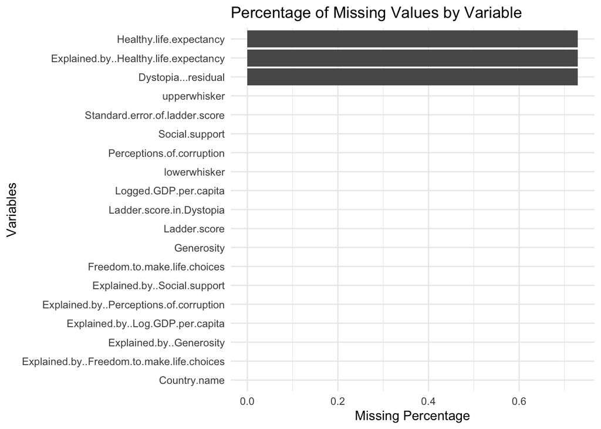

```r
ggplot(missing_df, aes(x = reorder(variable, missing_percent),
                    y = missing_percent)) +
    geom_bar(stat = "identity") +
    coord_flip() +
    theme_minimal() +
    labs(title = "Percentage of Missing Values by Variable",
        x = "Variables", y = "Missing Percentage")
```

#### 3. Data Cleaning and Transformation

Create a GDP category: Classify countries into High GDP or Low GDP based on whether their Logged.GDP.per.capita is above or below the median value. Hint: Use the median() function to find the median GDP, and ifelse() to categorize the countries. Clean the data: Remove any rows where the happiness score Ladder.score is missing

```r
whr_clean <- whr %>%
    mutate(# Create a GDP variable
    GDP = ifelse(Logged.GDP.per.capita >= median(whr$Logged.GDP.per.capita), "High GDP", "Low GDP")) %>%
    filter(!is.na(Ladder.score))  # Remove rows with missing ladder score values
```

#### 2. Data Summarization

Calculate average happiness scores: Group the dataset by GDP category (high vs. low GDP) and calculate the average happiness score Ladder.score for each group.

```r
country_stats <- whr_clean %>%
    group_by(GDP) %>%
    summarise(
        Avg_Happiness_Score = mean(Ladder.score)) %>%
    arrange(desc(Avg_Happiness_Score))
```

#### 3. Data Visualization

Create a box plot: Create a box plot that compares the happiness scores Ladder.score between high and low GDP countries. Use ggplot2 to create the plot.s)

Box Plot (Happiness Score by GDP):

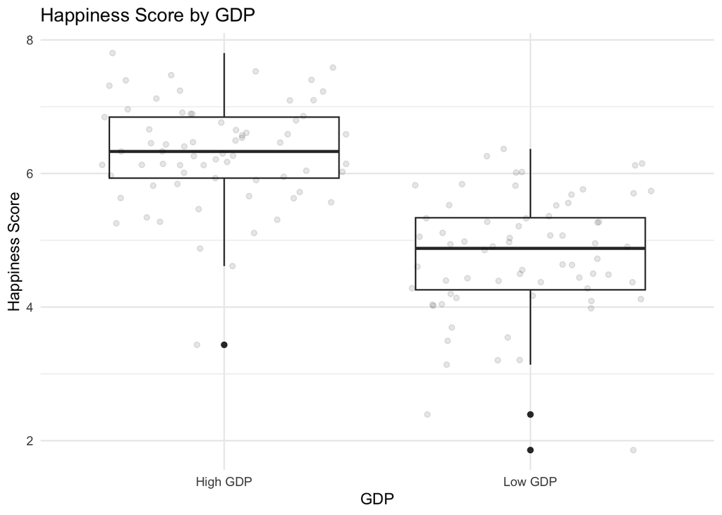

```r
box_plot <- ggplot(whr_clean,
                aes(x = GDP, y = Ladder.score)) +
    geom_boxplot() +
    geom_jitter(alpha = 0.1) +
    theme_minimal() +
    labs(title = "Happiness Score by GDP",
        x = "GDP", y = "Happiness Score")
print(box_plot)
```

#### 4. Statistical Analysis

Perform a t-test: Perform a t-test to compare the average happiness scores between high and low GDP countries. Interpret the result briefly (focus on the p-value).

```r
t_test_result <- t.test(Ladder.score ~ GDP, data = whr_clean)
print(t_test_result)
```

```
##
##  Welch Two Sample t-test
##
## data:  Ladder.score by GDP
## t = 10.779, df = 130.93, p-value < 2.2e-16
## alternative hypothesis: true difference in means between group High GDP and group Low GDP is not equal to 0
## 95 percent confidence interval:
##  1.262241 1.829667
## sample estimates:
## mean in group High GDP  mean in group Low GDP
##               6.307130               4.761176
```